# 20200123_study-ch06

20200123

6章 学習に関するテクニック

- 最適な重みパラメータを探索する最適化手法
- 重みパラメータの初期値
- ハイパーパラメータの設定方法  
  など

過学習の対応策

- Weight decay
- Dropout  
  などの正則化手法

# パラメータの更新

ニューラルネットワークの学習の目的 = 損失関数の値をできるだけ小さくするパラメータを見つけること  
最適化→最適なパラメータを見つける問題

↓

- 確率的勾配降下法 SGD  
  パラメータの勾配を手がかりに、勾配方向にパラメータを更新するというステップを何度も繰り返す

## SGDの実装

```python
class SGD:
    def __init__(self, lr=0.01):
        self.lr = lr


    def update(self, params, grads):
        for key in params.keys():
            params[key] -= self.lr * grads[key]
```

使い方

```python
optimizer = SGD()
optimizer = Momentum()
```

など

deeplearningのいろんなワークフレームでは、  
さまざまな最適化手法が実装されていて、カンタンに切り替えられる仕組みになっている

## SGDの欠点

勾配の方向が本来の最小値ではない方向を指しているかもしれない

例）

[figure not shown]

ジグザグ進んでしまって、非効率的

[figure not shown]

## SGDに代わる手法

### 1. Momentum

実装

common/optimiser.py

```python
class Momentum:

    """Momentum SGD"""

    def __init__(self, lr=0.01, momentum=0.9):
        self.lr = lr
        self.momentum = momentum
        self.v = None

    def update(self, params, grads):
        if self.v is None:
            self.v = {}
            for key, val in params.items():
                self.v[key] = np.zeros_like(val)

        for key in params.keys():
            self.v[key] = self.momentum*self.v[key] - self.lr*grads[key]
            params[key] += self.v[key]
```

[figure not shown]

### 2. AdaGrad

- 学習係数の減衰  
  学習が進むにつれて、学習係数を小さくする

最初は”大きく”学習し、次第に”小さく”学習する週報

AdaGradは、「一つひとつ」のパラメータに対して、オーダーメイドの値をこしらえる

```python
class AdaGrad:

    """AdaGrad"""

    def __init__(self, lr=0.01):
        self.lr = lr
        self.h = None

    def update(self, params, grads):
        if self.h is None:
            self.h = {}
            for key, val in params.items():
                self.h[key] = np.zeros_like(val)

        for key in params.keys():
            self.h[key] += grads[key] * grads[key]
            params[key] -= self.lr * grads[key] / (np.sqrt(self.h[key]) + 1e-7)
```

[figure not shown]

### 3.Adam

MomentumとAdaGradの融合版

```python
class Adam:

    """Adam (http://arxiv.org/abs/1412.6980v8)"""

    def __init__(self, lr=0.001, beta1=0.9, beta2=0.999):
        self.lr = lr
        self.beta1 = beta1
        self.beta2 = beta2
        self.iter = 0
        self.m = None
        self.v = None

    def update(self, params, grads):
        if self.m is None:
            self.m, self.v = {}, {}
            for key, val in params.items():
                self.m[key] = np.zeros_like(val)
                self.v[key] = np.zeros_like(val)

        self.iter += 1
        lr_t  = self.lr * np.sqrt(1.0 - self.beta2**self.iter) / (1.0 - self.beta1**self.iter)

        for key in params.keys():
            #self.m[key] = self.beta1*self.m[key] + (1-self.beta1)*grads[key]
            #self.v[key] = self.beta2*self.v[key] + (1-self.beta2)*(grads[key]**2)
            self.m[key] += (1 - self.beta1) * (grads[key] - self.m[key])
            self.v[key] += (1 - self.beta2) * (grads[key]**2 - self.v[key])

            params[key] -= lr_t * self.m[key] / (np.sqrt(self.v[key]) + 1e-7)

            #unbias_m += (1 - self.beta1) * (grads[key] - self.m[key]) # correct bias
            #unbisa_b += (1 - self.beta2) * (grads[key]*grads[key] - self.v[key]) # correct bias
            #params[key] += self.lr * unbias_m / (np.sqrt(unbisa_b) + 1e-7)
```

### 4.RMSProp

AdaGradは過去の勾配を２乗和として全て記録  
そのため学習を無限に進めれば更新料は0になり、全く更新されなくなる

この問題がを解決したRMSPropと違う手法も。  
RMSPropはかこ全ての勾配を均一に加算するのではなく、過去の勾配を徐々に忘れて、新しい勾配情報が大きく反映させるように計算される手法。  
これを「指数移動平均」と言う

## 4つの手法の比較

/Users/yamada/machine-learning/deep-learning-from-scratch/ch06/optimizer_compare_naive.py

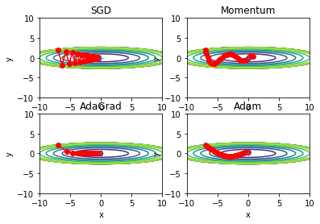

```python
# coding: utf-8
import sys, os
sys.path.append(os.pardir)  # 親ディレクトリのファイルをインポートするための設定
import numpy as np
import matplotlib.pyplot as plt
from collections import OrderedDict
from common.optimizer import *


def f(x, y):
    return x**2 / 20.0 + y**2


def df(x, y):
    return x / 10.0, 2.0*y

init_pos = (-7.0, 2.0)
params = {}
params['x'], params['y'] = init_pos[0], init_pos[1]
grads = {}
grads['x'], grads['y'] = 0, 0


optimizers = OrderedDict()
optimizers["SGD"] = SGD(lr=0.95)
optimizers["Momentum"] = Momentum(lr=0.1)
optimizers["AdaGrad"] = AdaGrad(lr=1.5)
optimizers["Adam"] = Adam(lr=0.3)

idx = 1

for key in optimizers:
    optimizer = optimizers[key]
    x_history = []
    y_history = []
    params['x'], params['y'] = init_pos[0], init_pos[1]

    for i in range(30):
        x_history.append(params['x'])
        y_history.append(params['y'])

        grads['x'], grads['y'] = df(params['x'], params['y'])
        optimizer.update(params, grads)


    x = np.arange(-10, 10, 0.01)
    y = np.arange(-5, 5, 0.01)

    X, Y = np.meshgrid(x, y)
    Z = f(X, Y)

    # for simple contour line
    mask = Z > 7
    Z[mask] = 0

    # plot
    plt.subplot(2, 2, idx)
    idx += 1
    plt.plot(x_history, y_history, 'o-', color="red")
    plt.contour(X, Y, Z)
    plt.ylim(-10, 10)
    plt.xlim(-10, 10)
    plt.plot(0, 0, '+')
    #colorbar()
    #spring()
    plt.title(key)
    plt.xlabel("x")
    plt.ylabel("y")

plt.show()
```

それぞれに得意な問題、不得意なものがある

MNISTで

```
===========iteration:0===========
SGD:2.2908901323839945
Momentum:2.3001149850090696
AdaGrad:2.104620533634102
Adam:2.2598952327191206
===========iteration:100===========
SGD:1.5921289050324046
Momentum:0.3218386707020719
AdaGrad:0.15956578378193664
Adam:0.2595388557487187
===========iteration:200===========
SGD:0.7427068367701316
Momentum:0.1547256012213133
AdaGrad:0.03741169373509174
Adam:0.08489872001567357
===========iteration:300===========
SGD:0.5716356893686116
Momentum:0.182797361326288
AdaGrad:0.08603913927263505
Adam:0.16333454328106828
===========iteration:400===========
SGD:0.4868357594951061
Momentum:0.16320637235956575
AdaGrad:0.08694204638572114
Adam:0.13910072803399737
===========iteration:500===========
SGD:0.3592600821594736
Momentum:0.13970575165878774
AdaGrad:0.09095249193936367
Adam:0.1296682232720982
===========iteration:600===========
SGD:0.3935482307660455
Momentum:0.17012581387094627
AdaGrad:0.04932417260971462
Adam:0.0642368093893096
===========iteration:700===========
SGD:0.39296281401032723
Momentum:0.21623011537129086
AdaGrad:0.08040110996929042
Adam:0.19965587268246732
```

[output cut: 45 more lines]

```
===========iteration:1700===========
SGD:0.1171010503542986
Momentum:0.01599657620858696
AdaGrad:0.011733419588407627
Adam:0.0063848227703481395
===========iteration:1800===========
SGD:0.22976950109547717
Momentum:0.05176040382671834
AdaGrad:0.023151481786985877
Adam:0.011593447729993848
===========iteration:1900===========
SGD:0.20162540198460338
Momentum:0.04226401925231702
AdaGrad:0.010848623737934302
Adam:0.037311962308139615
```

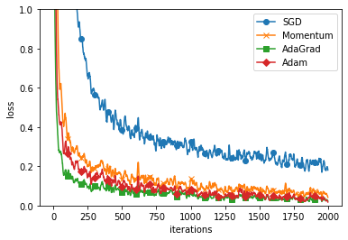

```python
# coding: utf-8
import os
import sys
sys.path.append(os.pardir)  # 親ディレクトリのファイルをインポートするための設定
import matplotlib.pyplot as plt
from dataset.mnist import load_mnist
from common.util import smooth_curve
from common.multi_layer_net import MultiLayerNet
from common.optimizer import *


# 0:MNISTデータの読み込み==========
(x_train, t_train), (x_test, t_test) = load_mnist(normalize=True)

train_size = x_train.shape[0]
batch_size = 128
max_iterations = 2000


# 1:実験の設定==========
optimizers = {}
optimizers['SGD'] = SGD()
optimizers['Momentum'] = Momentum()
optimizers['AdaGrad'] = AdaGrad()
optimizers['Adam'] = Adam()
#optimizers['RMSprop'] = RMSprop()

networks = {}
train_loss = {}
for key in optimizers.keys():
    networks[key] = MultiLayerNet(
        input_size=784, hidden_size_list=[100, 100, 100, 100],
        output_size=10)
    train_loss[key] = []


# 2:訓練の開始==========
for i in range(max_iterations):
    batch_mask = np.random.choice(train_size, batch_size)
    x_batch = x_train[batch_mask]
    t_batch = t_train[batch_mask]

    for key in optimizers.keys():
        grads = networks[key].gradient(x_batch, t_batch)
        optimizers[key].update(networks[key].params, grads)

        loss = networks[key].loss(x_batch, t_batch)
        train_loss[key].append(loss)

    if i % 100 == 0:
        print( "===========" + "iteration:" + str(i) + "===========")
        for key in optimizers.keys():
            loss = networks[key].loss(x_batch, t_batch)
            print(key + ":" + str(loss))


# 3.グラフの描画==========
markers = {"SGD": "o", "Momentum": "x", "AdaGrad": "s", "Adam": "D"}
x = np.arange(max_iterations)
for key in optimizers.keys():
    plt.plot(x, smooth_curve(train_loss[key]), marker=markers[key], markevery=100, label=key)
plt.xlabel("iterations")
plt.ylabel("loss")
plt.ylim(0, 1)
plt.legend()
plt.show()
```

# 重みの初期値

## 隠れ層のアクティベーション分布

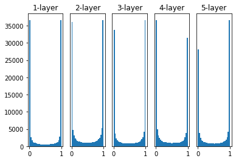

```python
# coding: utf-8
import numpy as np
import matplotlib.pyplot as plt


def sigmoid(x):
    return 1 / (1 + np.exp(-x))


def ReLU(x):
    return np.maximum(0, x)


def tanh(x):
    return np.tanh(x)

input_data = np.random.randn(1000, 100)  # 1000個のデータ
node_num = 100  # 各隠れ層のノード（ニューロン）の数
hidden_layer_size = 5  # 隠れ層が5層
activations = {}  # ここにアクティベーションの結果を格納する

x = input_data

for i in range(hidden_layer_size):
    if i != 0:
        x = activations[i-1]

    # 初期値の値をいろいろ変えて実験しよう！
    w = np.random.randn(node_num, node_num) * 1
    # w = np.random.randn(node_num, node_num) * 0.01
    # w = np.random.randn(node_num, node_num) * np.sqrt(1.0 / node_num)
    # w = np.random.randn(node_num, node_num) * np.sqrt(2.0 / node_num)


    a = np.dot(x, w)


    # 活性化関数の種類も変えて実験しよう！
    z = sigmoid(a)
    # z = ReLU(a)
    # z = tanh(a)

    activations[i] = z

# ヒストグラムを描画
for i, a in activations.items():
    plt.subplot(1, len(activations), i+1)
    plt.title(str(i+1) + "-layer")
    if i != 0: plt.yticks([], [])
    # plt.xlim(0.1, 1)
    # plt.ylim(0, 7000)
    plt.hist(a.flatten(), 30, range=(0,1))
plt.show()
```

↑ 重みの標準偏差＝1

重みの標準偏差＝0.01

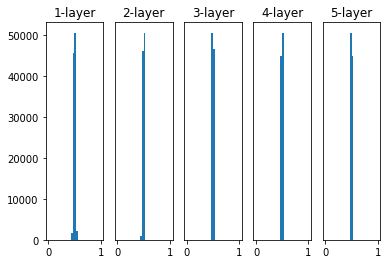

```python
for i in range(hidden_layer_size):
    if i != 0:
        x = activations[i-1]

    # 初期値の値をいろいろ変えて実験しよう！
    # w = np.random.randn(node_num, node_num) * 1
    w = np.random.randn(node_num, node_num) * 0.01
    # w = np.random.randn(node_num, node_num) * np.sqrt(1.0 / node_num)
    # w = np.random.randn(node_num, node_num) * np.sqrt(2.0 / node_num)


    a = np.dot(x, w)


    # 活性化関数の種類も変えて実験しよう！
    z = sigmoid(a)
    # z = ReLU(a)
    # z = tanh(a)

    activations[i] = z

# ヒストグラムを描画
for i, a in activations.items():
    plt.subplot(1, len(activations), i+1)
    plt.title(str(i+1) + "-layer")
    if i != 0: plt.yticks([], [])
    # plt.xlim(0.1, 1)
    # plt.ylim(0, 7000)
    plt.hist(a.flatten(), 30, range=(0,1))
plt.show()
```

### Xavierの初期値

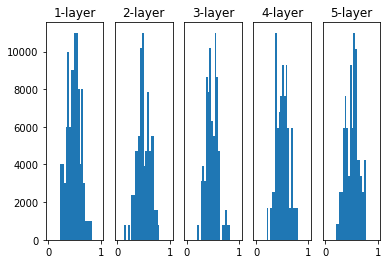

```python
for i in range(hidden_layer_size):
    if i != 0:
        x = activations[i-1]

    # 初期値の値をいろいろ変えて実験しよう！
    # w = np.random.randn(node_num, node_num) * 1
    # w = np.random.randn(node_num, node_num) * 0.01
    node_num = 100
    w = np.random.randn(node_num, node_num) * np.sqrt(1.0 / node_num)
    # w = np.random.randn(node_num, node_num) * np.sqrt(2.0 / node_num)


    a = np.dot(x, w)


    # 活性化関数の種類も変えて実験しよう！
    z = sigmoid(a)
    # z = ReLU(a)
    # z = tanh(a)

    activations[i] = z

# ヒストグラムを描画
for i, a in activations.items():
    plt.subplot(1, len(activations), i+1)
    plt.title(str(i+1) + "-layer")
    if i != 0: plt.yticks([], [])
    # plt.xlim(0.1, 1)
    # plt.ylim(0, 7000)
    plt.hist(a.flatten(), 30, range=(0,1))
plt.show()
```

## ReLUの場合の重みの初期値

Heの初期値、を使う

ニューラルネットワークの活性化関数がReLU関数の時はHeの初期値を用いて、それ以外の時はXivierの初期値を用いるとよい

## MNISTのデータセットで、重み初期値の比較

```
===========iteration:0===========
std=0.01:2.3024692162542753
Xavier:2.303636300483043
He:2.3761902490490083
===========iteration:100===========
std=0.01:2.3022902742942213
Xavier:2.2255879960352676
He:1.5997376878914262
===========iteration:200===========
std=0.01:2.302933318068715
Xavier:2.155798514661858
He:0.9753740004173578
===========iteration:300===========
std=0.01:2.2987976553938037
Xavier:1.728030140640496
He:0.5101695044239076
===========iteration:400===========
std=0.01:2.3022209614016735
Xavier:1.3944909960807683
He:0.5185456128870456
===========iteration:500===========
std=0.01:2.300195607245262
Xavier:0.8598640613414745
He:0.33185595964537823
===========iteration:600===========
std=0.01:2.303644469613671
Xavier:0.6860771834064022
He:0.33015574650128804
===========iteration:700===========
std=0.01:2.3050724156165634
Xavier:0.5099563773060336
He:0.2514783171816898
===========iteration:800===========
std=0.01:2.3024856718453264
Xavier:0.40111228493046064
He:0.2203759534698138
===========iteration:900===========
std=0.01:2.297343300789691
Xavier:0.34902805817914395
He:0.2065464656676662
```

[output cut: 25 more lines]

```
std=0.01:2.2975041580940028
Xavier:0.34487080089585254
He:0.18461398388578174
===========iteration:1700===========
std=0.01:2.2950232656693412
Xavier:0.29324492736758934
He:0.25786488295822874
===========iteration:1800===========
std=0.01:2.3004555177994255
Xavier:0.2508101456626637
He:0.14605117587906713
===========iteration:1900===========
std=0.01:2.302569966700034
Xavier:0.390704477289065
He:0.3174121845331632
```

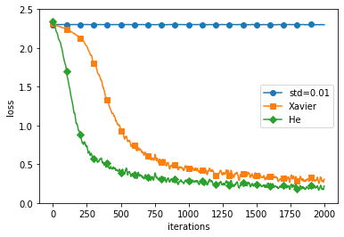

```python
# coding: utf-8
import os
import sys

sys.path.append(os.pardir)  # 親ディレクトリのファイルをインポートするための設定
import numpy as np
import matplotlib.pyplot as plt
from dataset.mnist import load_mnist
from common.util import smooth_curve
from common.multi_layer_net import MultiLayerNet
from common.optimizer import SGD


# 0:MNISTデータの読み込み==========
(x_train, t_train), (x_test, t_test) = load_mnist(normalize=True)

train_size = x_train.shape[0]
batch_size = 128
max_iterations = 2000


# 1:実験の設定==========
weight_init_types = {'std=0.01': 0.01, 'Xavier': 'sigmoid', 'He': 'relu'}
optimizer = SGD(lr=0.01)

networks = {}
train_loss = {}
for key, weight_type in weight_init_types.items():
    networks[key] = MultiLayerNet(input_size=784, hidden_size_list=[100, 100, 100, 100],
                                  output_size=10, weight_init_std=weight_type)
    train_loss[key] = []


# 2:訓練の開始==========
for i in range(max_iterations):
    batch_mask = np.random.choice(train_size, batch_size)
    x_batch = x_train[batch_mask]
    t_batch = t_train[batch_mask]

    for key in weight_init_types.keys():
        grads = networks[key].gradient(x_batch, t_batch)
        optimizer.update(networks[key].params, grads)

        loss = networks[key].loss(x_batch, t_batch)
        train_loss[key].append(loss)

    if i % 100 == 0:
        print("===========" + "iteration:" + str(i) + "===========")
        for key in weight_init_types.keys():
            loss = networks[key].loss(x_batch, t_batch)
            print(key + ":" + str(loss))


# 3.グラフの描画==========
markers = {'std=0.01': 'o', 'Xavier': 's', 'He': 'D'}
x = np.arange(max_iterations)
for key in weight_init_types.keys():
    plt.plot(x, smooth_curve(train_loss[key]), marker=markers[key], markevery=100, label=key)
plt.xlabel("iterations")
plt.ylabel("loss")
plt.ylim(0, 2.5)
plt.legend()
plt.show()
```

重みの初期値=スタートはとても大事

# Batch Normaliization

[figure not shown]

batch normの計算グラフ

[figure not shown]

## MNISTデータでbatch normの評価

```
============== 1/16 ==============
epoch:0 | 0.099 - 0.135
epoch:1 | 0.097 - 0.101
```

```
epoch:2 | 0.097 - 0.122
epoch:3 | 0.097 - 0.155
epoch:4 | 0.097 - 0.18
epoch:5 | 0.097 - 0.182
epoch:6 | 0.097 - 0.199
epoch:7 | 0.097 - 0.221
epoch:8 | 0.097 - 0.241
epoch:9 | 0.097 - 0.255
epoch:10 | 0.097 - 0.256
epoch:11 | 0.097 - 0.274
epoch:12 | 0.097 - 0.285
epoch:13 | 0.097 - 0.306
epoch:14 | 0.097 - 0.324
epoch:15 | 0.097 - 0.333
epoch:16 | 0.097 - 0.348
```

```
No handles with labels found to put in legend.
```

```
epoch:17 | 0.097 - 0.371
epoch:18 | 0.097 - 0.38
epoch:19 | 0.097 - 0.388
============== 2/16 ==============
epoch:0 | 0.099 - 0.091
epoch:1 | 0.097 - 0.085
epoch:2 | 0.097 - 0.137
epoch:3 | 0.097 - 0.182
epoch:4 | 0.097 - 0.222
epoch:5 | 0.097 - 0.247
epoch:6 | 0.097 - 0.279
epoch:7 | 0.097 - 0.3
epoch:8 | 0.097 - 0.33
epoch:9 | 0.097 - 0.35
epoch:10 | 0.097 - 0.372
epoch:11 | 0.097 - 0.396
epoch:12 | 0.097 - 0.409
epoch:13 | 0.097 - 0.435
epoch:14 | 0.097 - 0.446
epoch:15 | 0.097 - 0.467
epoch:16 | 0.097 - 0.49
epoch:17 | 0.097 - 0.504
```

```
No handles with labels found to put in legend.
```

```
epoch:18 | 0.097 - 0.512
epoch:19 | 0.097 - 0.526
============== 3/16 ==============
epoch:0 | 0.192 - 0.092
epoch:1 | 0.297 - 0.093
epoch:2 | 0.383 - 0.138
epoch:3 | 0.449 - 0.213
epoch:4 | 0.536 - 0.266
epoch:5 | 0.615 - 0.3
epoch:6 | 0.664 - 0.332
epoch:7 | 0.717 - 0.388
epoch:8 | 0.773 - 0.418
epoch:9 | 0.816 - 0.466
epoch:10 | 0.835 - 0.48
epoch:11 | 0.857 - 0.511
epoch:12 | 0.882 - 0.528
epoch:13 | 0.9 - 0.561
epoch:14 | 0.911 - 0.584
epoch:15 | 0.93 - 0.609
epoch:16 | 0.939 - 0.617
epoch:17 | 0.951 - 0.642
epoch:18 | 0.959 - 0.656
```

```
No handles with labels found to put in legend.
```

```
epoch:19 | 0.961 - 0.675
============== 4/16 ==============
epoch:0 | 0.143 - 0.087
epoch:1 | 0.274 - 0.126
epoch:2 | 0.426 - 0.212
epoch:3 | 0.526 - 0.308
epoch:4 | 0.583 - 0.372
epoch:5 | 0.636 - 0.432
epoch:6 | 0.668 - 0.486
epoch:7 | 0.699 - 0.542
epoch:8 | 0.729 - 0.589
epoch:9 | 0.745 - 0.619
epoch:10 | 0.765 - 0.648
epoch:11 | 0.784 - 0.687
epoch:12 | 0.802 - 0.701
epoch:13 | 0.809 - 0.717
epoch:14 | 0.813 - 0.736
epoch:15 | 0.822 - 0.756
epoch:16 | 0.843 - 0.774
```

```
No handles with labels found to put in legend.
```

```
epoch:17 | 0.852 - 0.781
epoch:18 | 0.864 - 0.791
epoch:19 | 0.868 - 0.806
============== 5/16 ==============
epoch:0 | 0.097 - 0.08
epoch:1 | 0.103 - 0.129
epoch:2 | 0.114 - 0.244
epoch:3 | 0.13 - 0.385
epoch:4 | 0.143 - 0.479
epoch:5 | 0.149 - 0.561
epoch:6 | 0.158 - 0.623
epoch:7 | 0.169 - 0.673
epoch:8 | 0.173 - 0.711
epoch:9 | 0.182 - 0.738
epoch:10 | 0.189 - 0.759
epoch:11 | 0.205 - 0.779
epoch:12 | 0.216 - 0.799
epoch:13 | 0.221 - 0.817
epoch:14 | 0.24 - 0.836
epoch:15 | 0.255 - 0.852
epoch:16 | 0.264 - 0.855
epoch:17 | 0.266 - 0.863
```

```
No handles with labels found to put in legend.
```

```
epoch:18 | 0.274 - 0.875
epoch:19 | 0.282 - 0.886
============== 6/16 ==============
epoch:0 | 0.179 - 0.128
epoch:1 | 0.138 - 0.194
epoch:2 | 0.151 - 0.418
epoch:3 | 0.141 - 0.618
epoch:4 | 0.117 - 0.694
epoch:5 | 0.145 - 0.74
epoch:6 | 0.15 - 0.777
epoch:7 | 0.174 - 0.806
epoch:8 | 0.154 - 0.826
epoch:9 | 0.148 - 0.836
epoch:10 | 0.145 - 0.85
epoch:11 | 0.154 - 0.867
epoch:12 | 0.14 - 0.876
epoch:13 | 0.176 - 0.884
epoch:14 | 0.152 - 0.9
epoch:15 | 0.17 - 0.911
epoch:16 | 0.116 - 0.922
epoch:17 | 0.116 - 0.928
```

```
No handles with labels found to put in legend.
```

```
epoch:18 | 0.194 - 0.935
epoch:19 | 0.129 - 0.945
============== 7/16 ==============
epoch:0 | 0.105 - 0.114
epoch:1 | 0.117 - 0.276
epoch:2 | 0.117 - 0.608
epoch:3 | 0.117 - 0.724
epoch:4 | 0.117 - 0.77
epoch:5 | 0.117 - 0.805
epoch:6 | 0.117 - 0.839
epoch:7 | 0.117 - 0.867
epoch:8 | 0.117 - 0.895
epoch:9 | 0.116 - 0.921
epoch:10 | 0.116 - 0.94
epoch:11 | 0.116 - 0.949
epoch:12 | 0.116 - 0.956
epoch:13 | 0.116 - 0.963
epoch:14 | 0.116 - 0.971
epoch:15 | 0.116 - 0.978
epoch:16 | 0.116 - 0.981
epoch:17 | 0.116 - 0.983
epoch:18 | 0.116 - 0.983
epoch:19 | 0.117 - 0.986
```

```
No handles with labels found to put in legend.
```

```
============== 8/16 ==============
epoch:0 | 0.089 - 0.138
epoch:1 | 0.117 - 0.429
epoch:2 | 0.117 - 0.7
epoch:3 | 0.117 - 0.795
epoch:4 | 0.117 - 0.858
epoch:5 | 0.117 - 0.91
epoch:6 | 0.117 - 0.942
epoch:7 | 0.117 - 0.948
epoch:8 | 0.117 - 0.966
epoch:9 | 0.117 - 0.978
epoch:10 | 0.117 - 0.984
epoch:11 | 0.117 - 0.985
epoch:12 | 0.117 - 0.992
epoch:13 | 0.117 - 0.996
epoch:14 | 0.117 - 0.998
epoch:15 | 0.117 - 0.999
epoch:16 | 0.117 - 1.0
epoch:17 | 0.117 - 1.0
epoch:18 | 0.117 - 1.0
```

```
No handles with labels found to put in legend.
```

```
epoch:19 | 0.117 - 1.0
============== 9/16 ==============
epoch:0 | 0.087 - 0.115
epoch:1 | 0.117 - 0.457
epoch:2 | 0.116 - 0.774
epoch:3 | 0.116 - 0.842
epoch:4 | 0.116 - 0.868
epoch:5 | 0.116 - 0.894
epoch:6 | 0.116 - 0.971
epoch:7 | 0.116 - 0.982
epoch:8 | 0.116 - 0.986
epoch:9 | 0.116 - 0.99
epoch:10 | 0.116 - 0.991
epoch:11 | 0.116 - 0.994
epoch:12 | 0.117 - 0.995
epoch:13 | 0.117 - 0.998
epoch:14 | 0.117 - 0.999
epoch:15 | 0.117 - 0.999
epoch:16 | 0.117 - 0.999
epoch:17 | 0.117 - 1.0
```

```
No handles with labels found to put in legend.
```

```
epoch:18 | 0.117 - 1.0
epoch:19 | 0.117 - 1.0
============== 10/16 ==============
epoch:0 | 0.117 - 0.105
epoch:1 | 0.116 - 0.611
epoch:2 | 0.116 - 0.767
epoch:3 | 0.116 - 0.842
epoch:4 | 0.116 - 0.863
epoch:5 | 0.117 - 0.92
epoch:6 | 0.117 - 0.928
epoch:7 | 0.117 - 0.978
epoch:8 | 0.117 - 0.985
epoch:9 | 0.117 - 0.99
epoch:10 | 0.117 - 0.83
epoch:11 | 0.117 - 0.982
epoch:12 | 0.117 - 0.98
epoch:13 | 0.117 - 0.992
epoch:14 | 0.117 - 0.982
epoch:15 | 0.117 - 0.996
epoch:16 | 0.117 - 0.996
epoch:17 | 0.117 - 0.997
```

```
No handles with labels found to put in legend.
```

```
epoch:18 | 0.116 - 0.997
epoch:19 | 0.116 - 0.997
============== 11/16 ==============
epoch:0 | 0.117 - 0.101
epoch:1 | 0.117 - 0.64
epoch:2 | 0.117 - 0.765
epoch:3 | 0.117 - 0.771
epoch:4 | 0.116 - 0.822
epoch:5 | 0.117 - 0.916
epoch:6 | 0.116 - 0.95
epoch:7 | 0.116 - 0.956
epoch:8 | 0.116 - 0.864
epoch:9 | 0.116 - 0.651
epoch:10 | 0.116 - 0.987
epoch:11 | 0.116 - 0.986
epoch:12 | 0.116 - 0.99
epoch:13 | 0.117 - 0.984
epoch:14 | 0.117 - 0.994
epoch:15 | 0.117 - 0.994
epoch:16 | 0.117 - 0.995
epoch:17 | 0.117 - 0.995
epoch:18 | 0.117 - 0.996
```

```
No handles with labels found to put in legend.
```

```
epoch:19 | 0.117 - 0.997
============== 12/16 ==============
epoch:0 | 0.1 - 0.242
epoch:1 | 0.117 - 0.552
epoch:2 | 0.117 - 0.581
epoch:3 | 0.117 - 0.704
epoch:4 | 0.117 - 0.752
epoch:5 | 0.117 - 0.778
epoch:6 | 0.117 - 0.786
epoch:7 | 0.117 - 0.806
epoch:8 | 0.117 - 0.822
epoch:9 | 0.117 - 0.861
epoch:10 | 0.117 - 0.861
epoch:11 | 0.117 - 0.862
epoch:12 | 0.117 - 0.871
epoch:13 | 0.117 - 0.873
epoch:14 | 0.117 - 0.888
epoch:15 | 0.117 - 0.811
epoch:16 | 0.116 - 0.89
epoch:17 | 0.117 - 0.893
epoch:18 | 0.117 - 0.894
```

```
No handles with labels found to put in legend.
```

```
epoch:19 | 0.116 - 0.897
============== 13/16 ==============
epoch:0 | 0.117 - 0.119
epoch:1 | 0.116 - 0.398
epoch:2 | 0.116 - 0.563
epoch:3 | 0.116 - 0.486
epoch:4 | 0.116 - 0.528
epoch:5 | 0.116 - 0.599
epoch:6 | 0.116 - 0.609
epoch:7 | 0.116 - 0.61
epoch:8 | 0.116 - 0.613
epoch:9 | 0.116 - 0.606
epoch:10 | 0.116 - 0.259
epoch:11 | 0.116 - 0.595
epoch:12 | 0.116 - 0.498
epoch:13 | 0.116 - 0.605
epoch:14 | 0.116 - 0.605
epoch:15 | 0.116 - 0.679
epoch:16 | 0.116 - 0.693
epoch:17 | 0.117 - 0.678
epoch:18 | 0.117 - 0.692
epoch:19 | 0.117 - 0.76
```

```
No handles with labels found to put in legend.
```

```
============== 14/16 ==============
epoch:0 | 0.094 - 0.093
epoch:1 | 0.094 - 0.339
epoch:2 | 0.116 - 0.46
epoch:3 | 0.116 - 0.496
epoch:4 | 0.116 - 0.462
epoch:5 | 0.116 - 0.498
epoch:6 | 0.116 - 0.517
epoch:7 | 0.116 - 0.513
epoch:8 | 0.116 - 0.512
epoch:9 | 0.116 - 0.52
epoch:10 | 0.116 - 0.518
epoch:11 | 0.116 - 0.519
epoch:12 | 0.116 - 0.524
epoch:13 | 0.117 - 0.523
epoch:14 | 0.116 - 0.525
epoch:15 | 0.116 - 0.525
epoch:16 | 0.117 - 0.516
epoch:17 | 0.117 - 0.521
epoch:18 | 0.117 - 0.526
epoch:19 | 0.117 - 0.526
```

```
No handles with labels found to put in legend.
```

```
============== 15/16 ==============
epoch:0 | 0.116 - 0.164
epoch:1 | 0.116 - 0.32
epoch:2 | 0.117 - 0.453
epoch:3 | 0.116 - 0.475
epoch:4 | 0.116 - 0.484
epoch:5 | 0.116 - 0.488
epoch:6 | 0.117 - 0.485
epoch:7 | 0.117 - 0.48
epoch:8 | 0.117 - 0.5
epoch:9 | 0.117 - 0.504
epoch:10 | 0.117 - 0.503
epoch:11 | 0.117 - 0.509
epoch:12 | 0.117 - 0.508
epoch:13 | 0.117 - 0.51
epoch:14 | 0.117 - 0.51
epoch:15 | 0.117 - 0.511
epoch:16 | 0.117 - 0.533
```

```
No handles with labels found to put in legend.
```

```
epoch:17 | 0.117 - 0.523
epoch:18 | 0.117 - 0.509
epoch:19 | 0.117 - 0.51
============== 16/16 ==============
epoch:0 | 0.117 - 0.181
epoch:1 | 0.105 - 0.19
epoch:2 | 0.105 - 0.333
epoch:3 | 0.117 - 0.353
epoch:4 | 0.117 - 0.401
epoch:5 | 0.117 - 0.412
epoch:6 | 0.117 - 0.416
epoch:7 | 0.117 - 0.42
epoch:8 | 0.117 - 0.421
epoch:9 | 0.117 - 0.427
epoch:10 | 0.117 - 0.426
epoch:11 | 0.117 - 0.419
epoch:12 | 0.116 - 0.421
epoch:13 | 0.116 - 0.425
epoch:14 | 0.116 - 0.423
epoch:15 | 0.116 - 0.426
epoch:16 | 0.116 - 0.429
epoch:17 | 0.116 - 0.424
epoch:18 | 0.116 - 0.418
epoch:19 | 0.116 - 0.424
```

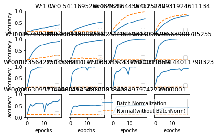

```python
# coding: utf-8
import sys, os
sys.path.append(os.pardir)  # 親ディレクトリのファイルをインポートするための設定
import numpy as np
import matplotlib.pyplot as plt
from dataset.mnist import load_mnist
from common.multi_layer_net_extend import MultiLayerNetExtend
from common.optimizer import SGD, Adam

(x_train, t_train), (x_test, t_test) = load_mnist(normalize=True)

# 学習データを削減
x_train = x_train[:1000]
t_train = t_train[:1000]

max_epochs = 20
train_size = x_train.shape[0]
batch_size = 100
learning_rate = 0.01


def __train(weight_init_std):
    bn_network = MultiLayerNetExtend(input_size=784, hidden_size_list=[100, 100, 100, 100, 100], output_size=10,
                                    weight_init_std=weight_init_std, use_batchnorm=True)
    network = MultiLayerNetExtend(input_size=784, hidden_size_list=[100, 100, 100, 100, 100], output_size=10,
                                weight_init_std=weight_init_std)
    optimizer = SGD(lr=learning_rate)

    train_acc_list = []
    bn_train_acc_list = []

    iter_per_epoch = max(train_size / batch_size, 1)
    epoch_cnt = 0

    for i in range(1000000000):
        batch_mask = np.random.choice(train_size, batch_size)
        x_batch = x_train[batch_mask]
        t_batch = t_train[batch_mask]

        for _network in (bn_network, network):
            grads = _network.gradient(x_batch, t_batch)
            optimizer.update(_network.params, grads)

        if i % iter_per_epoch == 0:
            train_acc = network.accuracy(x_train, t_train)
            bn_train_acc = bn_network.accuracy(x_train, t_train)
            train_acc_list.append(train_acc)
            bn_train_acc_list.append(bn_train_acc)

            print("epoch:" + str(epoch_cnt) + " | " + str(train_acc) + " - " + str(bn_train_acc))

            epoch_cnt += 1
            if epoch_cnt >= max_epochs:
                break

    return train_acc_list, bn_train_acc_list


# 3.グラフの描画==========
weight_scale_list = np.logspace(0, -4, num=16)
x = np.arange(max_epochs)

for i, w in enumerate(weight_scale_list):
    print( "============== " + str(i+1) + "/16" + " ==============")
    train_acc_list, bn_train_acc_list = __train(w)

    plt.subplot(4,4,i+1)
    plt.title("W:" + str(w))
    if i == 15:
        plt.plot(x, bn_train_acc_list, label='Batch Normalization', markevery=2)
        plt.plot(x, train_acc_list, linestyle = "--", label='Normal(without BatchNorm)', markevery=2)
    else:
        plt.plot(x, bn_train_acc_list, markevery=2)
        plt.plot(x, train_acc_list, linestyle="--", markevery=2)

    plt.ylim(0, 1.0)
    if i % 4:
        plt.yticks([])
    else:
        plt.ylabel("accuracy")
    if i < 12:
        plt.xticks([])
    else:
        plt.xlabel("epochs")
    plt.legend(loc='lower right')

plt.show()
```

# 正則化

## 過学習

過学習になる原因

- パラメータを大量にもち、表現力の高いモデルであること
- 訓練データが少ないこと

わざと過学習になるようなデータでみてみる

## Weight Decay（荷重減衰）

```
epoch:0, train acc:0.09333333333333334, test acc:0.1055
epoch:1, train acc:0.10666666666666667, test acc:0.1134
epoch:2, train acc:0.11666666666666667, test acc:0.1239
epoch:3, train acc:0.13333333333333333, test acc:0.133
epoch:4, train acc:0.15, test acc:0.1452
epoch:5, train acc:0.17666666666666667, test acc:0.1583
epoch:6, train acc:0.19666666666666666, test acc:0.1699
epoch:7, train acc:0.23, test acc:0.1845
epoch:8, train acc:0.25666666666666665, test acc:0.2002
epoch:9, train acc:0.29333333333333333, test acc:0.2181
epoch:10, train acc:0.31, test acc:0.2346
epoch:11, train acc:0.35333333333333333, test acc:0.2585
epoch:12, train acc:0.38, test acc:0.2766
epoch:13, train acc:0.42, test acc:0.3001
epoch:14, train acc:0.43333333333333335, test acc:0.3297
epoch:15, train acc:0.44, test acc:0.342
epoch:16, train acc:0.44666666666666666, test acc:0.3522
epoch:17, train acc:0.4866666666666667, test acc:0.3668
epoch:18, train acc:0.47333333333333333, test acc:0.3726
epoch:19, train acc:0.48, test acc:0.3809
epoch:20, train acc:0.4866666666666667, test acc:0.3966
epoch:21, train acc:0.49666666666666665, test acc:0.4013
epoch:22, train acc:0.51, test acc:0.4038
epoch:23, train acc:0.54, test acc:0.4186
epoch:24, train acc:0.55, test acc:0.4234
epoch:25, train acc:0.54, test acc:0.4285
epoch:26, train acc:0.56, test acc:0.4337
epoch:27, train acc:0.5833333333333334, test acc:0.4471
epoch:28, train acc:0.5866666666666667, test acc:0.4415
epoch:29, train acc:0.5733333333333334, test acc:0.438
epoch:30, train acc:0.5833333333333334, test acc:0.4458
epoch:31, train acc:0.5666666666666667, test acc:0.4495
epoch:32, train acc:0.58, test acc:0.4585
epoch:33, train acc:0.5633333333333334, test acc:0.445
epoch:34, train acc:0.55, test acc:0.4469
epoch:35, train acc:0.5866666666666667, test acc:0.4608
epoch:36, train acc:0.6333333333333333, test acc:0.4772
epoch:37, train acc:0.6466666666666666, test acc:0.4946
epoch:38, train acc:0.6433333333333333, test acc:0.4955
epoch:39, train acc:0.6566666666666666, test acc:0.5035
```

[output cut: 146 more lines]

```
epoch:186, train acc:0.88, test acc:0.6774
epoch:187, train acc:0.84, test acc:0.6594
epoch:188, train acc:0.84, test acc:0.6646
epoch:189, train acc:0.8633333333333333, test acc:0.6775
epoch:190, train acc:0.84, test acc:0.6708
epoch:191, train acc:0.8633333333333333, test acc:0.6763
epoch:192, train acc:0.85, test acc:0.6686
epoch:193, train acc:0.8433333333333334, test acc:0.6712
epoch:194, train acc:0.8733333333333333, test acc:0.6809
epoch:195, train acc:0.8566666666666667, test acc:0.6715
epoch:196, train acc:0.86, test acc:0.6814
epoch:197, train acc:0.8833333333333333, test acc:0.6841
epoch:198, train acc:0.89, test acc:0.6924
epoch:199, train acc:0.8733333333333333, test acc:0.6901
epoch:200, train acc:0.8766666666666667, test acc:0.6807
```

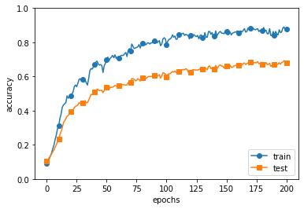

```python
# coding: utf-8
import os
import sys

sys.path.append(os.pardir)  # 親ディレクトリのファイルをインポートするための設定
import numpy as np
import matplotlib.pyplot as plt
from dataset.mnist import load_mnist
from common.multi_layer_net import MultiLayerNet
from common.optimizer import SGD

(x_train, t_train), (x_test, t_test) = load_mnist(normalize=True)

# 過学習を再現するために、学習データを削減
x_train = x_train[:300]
t_train = t_train[:300]

# weight decay（荷重減衰）の設定 =======================
#weight_decay_lambda = 0 # weight decayを使用しない場合
weight_decay_lambda = 0.1
# ====================================================

network = MultiLayerNet(input_size=784, hidden_size_list=[100, 100, 100, 100, 100, 100], output_size=10,
                        weight_decay_lambda=weight_decay_lambda)
optimizer = SGD(lr=0.01)

max_epochs = 201
train_size = x_train.shape[0]
batch_size = 100

train_loss_list = []
train_acc_list = []
test_acc_list = []

iter_per_epoch = max(train_size / batch_size, 1)
epoch_cnt = 0

for i in range(1000000000):
    batch_mask = np.random.choice(train_size, batch_size)
    x_batch = x_train[batch_mask]
    t_batch = t_train[batch_mask]

    grads = network.gradient(x_batch, t_batch)
    optimizer.update(network.params, grads)

    if i % iter_per_epoch == 0:
        train_acc = network.accuracy(x_train, t_train)
        test_acc = network.accuracy(x_test, t_test)
        train_acc_list.append(train_acc)
        test_acc_list.append(test_acc)

        print("epoch:" + str(epoch_cnt) + ", train acc:" + str(train_acc) + ", test acc:" + str(test_acc))

        epoch_cnt += 1
        if epoch_cnt >= max_epochs:
            break


# 3.グラフの描画==========
markers = {'train': 'o', 'test': 's'}
x = np.arange(max_epochs)
plt.plot(x, train_acc_list, marker='o', label='train', markevery=10)
plt.plot(x, test_acc_list, marker='s', label='test', markevery=10)
plt.xlabel("epochs")
plt.ylabel("accuracy")
plt.ylim(0, 1.0)
plt.legend(loc='lower right')
plt.show()
```

## Dropout

[figure not shown]

実装

```
train loss:2.316830196126176
=== epoch:1, train acc:0.07666666666666666, test acc:0.0795 ===
train loss:2.3173000474583585
train loss:2.3196377566791497
train loss:2.322924249356363
=== epoch:2, train acc:0.07666666666666666, test acc:0.0792 ===
train loss:2.317805382162303
train loss:2.313338415191025
train loss:2.312856568197229
=== epoch:3, train acc:0.07333333333333333, test acc:0.08 ===
train loss:2.317827765295087
train loss:2.324780458129359
train loss:2.3204702195728344
=== epoch:4, train acc:0.08, test acc:0.0799 ===
train loss:2.3237859487451247
train loss:2.3146296996566584
train loss:2.3148495139912315
=== epoch:5, train acc:0.07333333333333333, test acc:0.0818 ===
train loss:2.3171987204303237
train loss:2.311808811358027
train loss:2.3160203153055026
=== epoch:6, train acc:0.08, test acc:0.0819 ===
train loss:2.308453026137199
train loss:2.309282009993517
train loss:2.307217386114506
=== epoch:7, train acc:0.09, test acc:0.0836 ===
train loss:2.31023479116304
train loss:2.317646455086578
train loss:2.31988568950272
=== epoch:8, train acc:0.08666666666666667, test acc:0.0841 ===
train loss:2.3060714400277833
train loss:2.3167883532301095
train loss:2.3124583211891787
=== epoch:9, train acc:0.08666666666666667, test acc:0.0847 ===
train loss:2.315302363505145
train loss:2.315124855787512
train loss:2.3150666903938397
=== epoch:10, train acc:0.09666666666666666, test acc:0.0849 ===
train loss:2.3171238641613785
train loss:2.306035596139526
```

[output cut: 1151 more lines]

```
train loss:1.5387371454307186
train loss:1.5702109557763273
=== epoch:299, train acc:0.6733333333333333, test acc:0.5115 ===
train loss:1.4825536917925413
train loss:1.526037373508838
train loss:1.528730289187758
=== epoch:300, train acc:0.6733333333333333, test acc:0.5124 ===
train loss:1.548492369782928
train loss:1.4877992615063362
train loss:1.5646685528276034
=== epoch:301, train acc:0.6766666666666666, test acc:0.5243 ===
train loss:1.461221020637317
train loss:1.4521040771352358
=============== Final Test Accuracy ===============
test acc:0.5242
```

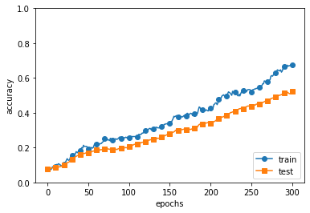

```python
# coding: utf-8
import os
import sys
sys.path.append(os.pardir)  # 親ディレクトリのファイルをインポートするための設定
import numpy as np
import matplotlib.pyplot as plt
from dataset.mnist import load_mnist
from common.multi_layer_net_extend import MultiLayerNetExtend
from common.trainer import Trainer

(x_train, t_train), (x_test, t_test) = load_mnist(normalize=True)

# 過学習を再現するために、学習データを削減
x_train = x_train[:300]
t_train = t_train[:300]

# Dropuoutの有無、割り合いの設定 ========================
use_dropout = True  # Dropoutなしのときの場合はFalseに
dropout_ratio = 0.2
# ====================================================

network = MultiLayerNetExtend(input_size=784, hidden_size_list=[100, 100, 100, 100, 100, 100],
                              output_size=10, use_dropout=use_dropout, dropout_ration=dropout_ratio)
trainer = Trainer(network, x_train, t_train, x_test, t_test,
                  epochs=301, mini_batch_size=100,
                  optimizer='sgd', optimizer_param={'lr': 0.01}, verbose=True)
trainer.train()

train_acc_list, test_acc_list = trainer.train_acc_list, trainer.test_acc_list

# グラフの描画==========
markers = {'train': 'o', 'test': 's'}
x = np.arange(len(train_acc_list))
plt.plot(x, train_acc_list, marker='o', label='train', markevery=10)
plt.plot(x, test_acc_list, marker='s', label='test', markevery=10)
plt.xlabel("epochs")
plt.ylabel("accuracy")
plt.ylim(0, 1.0)
plt.legend(loc='lower right')
plt.show()
```

# ハイパーパラメータの検証

人間が決めるパラメータ

- 各層のニューロンの数
- バッチサイズ
- パラメータの更新の際の学習係数
- Weight decay

注意点

- テストデータで、ハイパーパラメータの性能を評価してはいけない
- 検証データ = ハイパーパラメータの調整用のデータ

### 実装

訓練データのうち、20%を検証データとして、先に分離

```python
def shuffle_dataset(x, t):
    """データセットのシャッフルを行う

    Parameters
    ----------
    x : 訓練データ
    t : 教師データ

    Returns
    -------
    x, t : シャッフルを行った訓練データと教師データ
    """
    permutation = np.random.permutation(x.shape[0])
    x = x[permutation,:] if x.ndim == 2 else x[permutation,:,:,:]
    t = t[permutation]

    return x, t
```

```python
(x_train, t_train), (x_test, t_test) = load_mnist()

# 訓練データをシャッフル
x_train, t_train = shuffle_dataset(x_train, t_train)

# 検証データの分割
validation_rate = 0.20
validation_num = int(x_train.shape[0] * validation_rate)

x_val = x_train[:validation_num]
t_val = t_train[:validation_num]
x_train = x_train[validation_num:]
t_train = t_train[validation_num:]
```

### ハイパーパラメータの最適化

- STEP0  
  ハイパーパラメータの範囲を指定する：最初はざっくりと指定でOK  
  10のべき乗のスケール
- STEP1  
  設定されたハイパーパラメータの範囲からランダムにサンプリングする
- STEP2  
  STEP1でサンプリングされたハイパーパラメータの値を使用して学習を行い、 喧騒データの認識精度を評価する （ただし、エポックは小さく設定）
- STEP3  
  STEP2１とSTEP2wpある回数（１００回など）繰り返し、それらの認識精度の結果から ハイパーパラメータの範囲を狭める

実装

0.001 ~ 1000の対数スケールで

↓ランダム

```python
10 ** np.random.uniform(-3, 3)
```

```
0.0033859531716307215
```

```python
10 ** np.random.uniform(-3, 3)
```

```
74.44213239807132
```

実行

```
val acc:0.09 | lr:2.253308268577158e-06, weight decay:1.6522727191720265e-06
val acc:0.08 | lr:5.7096144724533315e-06, weight decay:2.1657926173842897e-07
val acc:0.09 | lr:5.139246095257825e-06, weight decay:3.2261106215422428e-06
val acc:0.11 | lr:7.184834998975917e-05, weight decay:8.765347488730685e-07
val acc:0.06 | lr:2.5938233883928088e-06, weight decay:1.3165960188446025e-07
val acc:0.16 | lr:5.936336701447274e-05, weight decay:5.2145131045623195e-05
val acc:0.35 | lr:0.0012480176711182906, weight decay:2.6971768406859075e-08
val acc:0.11 | lr:1.5323342749042957e-06, weight decay:8.461028512993586e-05
val acc:0.07 | lr:4.117867581545159e-05, weight decay:1.2794215350513472e-06
val acc:0.17 | lr:0.00026735744224305546, weight decay:7.807941146350253e-06
val acc:0.07 | lr:3.914114816839833e-05, weight decay:1.708437364212412e-05
val acc:0.45 | lr:0.002486752643295548, weight decay:2.640119675187666e-05
val acc:0.07 | lr:2.647141777303554e-05, weight decay:6.360932265456719e-05
val acc:0.42 | lr:0.0021678426134727116, weight decay:8.403415634650147e-06
val acc:0.02 | lr:2.7813155396362735e-06, weight decay:8.362389260020906e-05
val acc:0.09 | lr:1.761679762133725e-06, weight decay:2.764385485585537e-05
val acc:0.07 | lr:8.53358811707042e-05, weight decay:7.352485643496455e-08
val acc:0.33 | lr:0.005265223793780446, weight decay:2.80682085784969e-05
val acc:0.2 | lr:0.0015491375451392759, weight decay:3.278070457321848e-05
val acc:0.18 | lr:0.0009967283784788265, weight decay:1.3173098450984714e-05
val acc:0.11 | lr:0.00020225018701193443, weight decay:2.390550789101763e-06
val acc:0.1 | lr:0.00011126759430367636, weight decay:6.7417843328425e-05
val acc:0.09 | lr:3.812967049418719e-05, weight decay:7.074592750409509e-06
val acc:0.44 | lr:0.00214440398326461, weight decay:1.2591696862034055e-06
val acc:0.08 | lr:1.3490095882683697e-06, weight decay:2.8161558394478003e-06
val acc:0.07 | lr:2.691940546079193e-05, weight decay:3.0209451482829294e-05
val acc:0.11 | lr:1.788474933941453e-05, weight decay:3.762872583175068e-05
val acc:0.76 | lr:0.006865812128277583, weight decay:1.962401857125515e-08
val acc:0.08 | lr:1.2216414216313121e-05, weight decay:1.1909734711831338e-08
val acc:0.08 | lr:5.440962910737236e-05, weight decay:4.4097752557044243e-07
val acc:0.08 | lr:2.192276428119042e-05, weight decay:3.678863717228991e-06
val acc:0.06 | lr:8.931170239531258e-06, weight decay:1.7063485593177126e-07
val acc:0.78 | lr:0.008826090588732054, weight decay:2.1140308504737672e-07
val acc:0.11 | lr:0.0001241526858037281, weight decay:9.255241034015351e-07
val acc:0.1 | lr:1.868233969612307e-05, weight decay:2.6264734617725083e-08
val acc:0.08 | lr:2.4063405591228117e-06, weight decay:7.721797012352608e-05
val acc:0.11 | lr:0.0005805161593682246, weight decay:5.507756179898826e-07
val acc:0.53 | lr:0.004258251834538704, weight decay:3.0669864195709684e-05
val acc:0.12 | lr:0.0005430528550806234, weight decay:3.9988877555501605e-05
val acc:0.1 | lr:0.00046238193228179114, weight decay:6.562285839054716e-06
```

[output cut: 66 more lines]

```
Best-6(val acc:0.67) | lr:0.006322329459282604, weight decay:2.672482761787948e-06
Best-7(val acc:0.67) | lr:0.005312415170404017, weight decay:9.554339973415868e-06
Best-8(val acc:0.67) | lr:0.008394980424862915, weight decay:5.768035442935908e-06
Best-9(val acc:0.63) | lr:0.004581869211943733, weight decay:4.527227661242636e-05
Best-10(val acc:0.61) | lr:0.0033999136190028217, weight decay:7.73106895313683e-05
Best-11(val acc:0.6) | lr:0.003488265172469996, weight decay:4.252510077177557e-08
Best-12(val acc:0.53) | lr:0.004258251834538704, weight decay:3.0669864195709684e-05
Best-13(val acc:0.52) | lr:0.0035984030472459745, weight decay:9.734774329951814e-08
Best-14(val acc:0.51) | lr:0.002866959844308043, weight decay:2.7302272323653006e-07
Best-15(val acc:0.48) | lr:0.001754561872316483, weight decay:3.766738234183007e-06
Best-16(val acc:0.47) | lr:0.0018662336917781878, weight decay:2.9606461611405106e-07
Best-17(val acc:0.45) | lr:0.002486752643295548, weight decay:2.640119675187666e-05
Best-18(val acc:0.44) | lr:0.00214440398326461, weight decay:1.2591696862034055e-06
Best-19(val acc:0.44) | lr:0.0033962513298355992, weight decay:3.4111476910734857e-07
Best-20(val acc:0.42) | lr:0.0021678426134727116, weight decay:8.403415634650147e-06
```

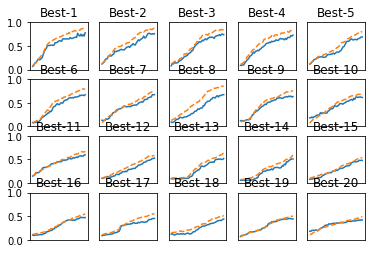

```python
# coding: utf-8
import sys, os
sys.path.append(os.pardir)  # 親ディレクトリのファイルをインポートするための設定
import numpy as np
import matplotlib.pyplot as plt
from dataset.mnist import load_mnist
from common.multi_layer_net import MultiLayerNet
from common.util import shuffle_dataset
from common.trainer import Trainer

(x_train, t_train), (x_test, t_test) = load_mnist(normalize=True)

# 高速化のため訓練データの削減
x_train = x_train[:500]
t_train = t_train[:500]

# 検証データの分離
validation_rate = 0.20
validation_num = int(x_train.shape[0] * validation_rate)
x_train, t_train = shuffle_dataset(x_train, t_train)
x_val = x_train[:validation_num]
t_val = t_train[:validation_num]
x_train = x_train[validation_num:]
t_train = t_train[validation_num:]


def __train(lr, weight_decay, epocs=50):
    network = MultiLayerNet(input_size=784, hidden_size_list=[100, 100, 100, 100, 100, 100],
                            output_size=10, weight_decay_lambda=weight_decay)
    trainer = Trainer(network, x_train, t_train, x_val, t_val,
                      epochs=epocs, mini_batch_size=100,
                      optimizer='sgd', optimizer_param={'lr': lr}, verbose=False)
    trainer.train()

    return trainer.test_acc_list, trainer.train_acc_list


# ハイパーパラメータのランダム探索======================================
optimization_trial = 100
results_val = {}
results_train = {}
for _ in range(optimization_trial):
    # 探索したハイパーパラメータの範囲を指定===============
    weight_decay = 10 ** np.random.uniform(-8, -4)
    lr = 10 ** np.random.uniform(-6, -2)
    # ================================================

    val_acc_list, train_acc_list = __train(lr, weight_decay)
    print("val acc:" + str(val_acc_list[-1]) + " | lr:" + str(lr) + ", weight decay:" + str(weight_decay))
    key = "lr:" + str(lr) + ", weight decay:" + str(weight_decay)
    results_val[key] = val_acc_list
    results_train[key] = train_acc_list

# グラフの描画========================================================
print("=========== Hyper-Parameter Optimization Result ===========")
graph_draw_num = 20
col_num = 5
row_num = int(np.ceil(graph_draw_num / col_num))
i = 0

for key, val_acc_list in sorted(results_val.items(), key=lambda x:x[1][-1], reverse=True):
    print("Best-" + str(i+1) + "(val acc:" + str(val_acc_list[-1]) + ") | " + key)

    plt.subplot(row_num, col_num, i+1)
    plt.title("Best-" + str(i+1))
    plt.ylim(0.0, 1.0)
    if i % 5: plt.yticks([])
    plt.xticks([])
    x = np.arange(len(val_acc_list))
    plt.plot(x, val_acc_list)
    plt.plot(x, results_train[key], "--")
    i += 1

    if i >= graph_draw_num:
        break

plt.show()
```

↓これの値を見比べて、よさそうな値のレンジを決める

=========== Hyper-Parameter Optimization Result =========== Best-1(val acc:0.78) | lr:0.008826090588732054, weight decay:2.1140308504737672e-07 Best-2(val acc:0.76) | lr:0.006865812128277583, weight decay:1.962401857125515e-08 Best-3(val acc:0.74) | lr:0.009141949202323729, weight decay:1.012187054329361e-06 Best-4(val acc:0.73) | lr:0.006498731371758282, weight decay:2.7106290823082956e-07 Best-5(val acc:0.69) | lr:0.007221162979746968, weight decay:1.0245763380953908e-07 Best-6(val acc:0.67) | lr:0.006322329459282604, weight decay:2.672482761787948e-06 Best-7(val acc:0.67) | lr:0.005312415170404017, weight decay:9.554339973415868e-06 Best-8(val acc:0.67) | lr:0.008394980424862915, weight decay:5.768035442935908e-06 Best-9(val acc:0.63) | lr:0.004581869211943733, weight decay:4.527227661242636e-05 Best-10(val acc:0.61) | lr:0.0033999136190028217, weight decay:7.73106895313683e-05 Best-11(val acc:0.6) | lr:0.003488265172469996, weight decay:4.252510077177557e-08 Best-12(val acc:0.53) | lr:0.004258251834538704, weight decay:3.0669864195709684e-05 Best-13(val acc:0.52) | lr:0.0035984030472459745, weight decay:9.734774329951814e-08 Best-14(val acc:0.51) | lr:0.002866959844308043, weight decay:2.7302272323653006e-07 Best-15(val acc:0.48) | lr:0.001754561872316483, weight decay:3.766738234183007e-06 Best-16(val acc:0.47) | lr:0.0018662336917781878, weight decay:2.9606461611405106e-07 Best-17(val acc:0.45) | lr:0.002486752643295548, weight decay:2.640119675187666e-05 Best-18(val acc:0.44) | lr:0.00214440398326461, weight decay:1.2591696862034055e-06 Best-19(val acc:0.44) | lr:0.0033962513298355992, weight decay:3.4111476910734857e-07 Best-20(val acc:0.42) | lr:0.0021678426134727116, weight decay:8.403415634650147e-06